# Project 4: Melanoma Classification

# **Experimentation with other algorithms**

```python
import subprocess
from sklearn.metrics import mean_squared_error

def train_sklearn_model(model, train_x, train_y, val_x, val_y):
    model.fit(train_x, train_y)
    pred = model.predict(val_x)
    r_square,rmse = calculate_regression_goodness_of_fit(np.array(val_y),pred)
    return model,r_square,rmse
```

**AdaBoost Regressor**

```python
from sklearn.ensemble import AdaBoostRegressor

ada_params = {
    'n_estimators':200,
    'learning_rate':0.1,
    'loss':'linear',
}
ada_model = AdaBoostRegressor(**ada_params)
_,r_square_ada,rmse_ada_woef = train_sklearn_model(ada_model, x_train, y_train, x_valid, y_valid)
```

[figure not shown]

**Decision Tree Regressor**

```python
from sklearn.tree import DecisionTreeRegressor

dt_params = {
    'criterion':'mse',
    'max_depth':20,
    'min_samples_leaf':20,
}
dt_model = DecisionTreeRegressor(**dt_params)
_,r_square_dt,rmse_dt_woef = train_sklearn_model(dt_model, x_train, y_train,  x_valid, y_valid)
```

**Extra Tree Regressor**

```python
from sklearn.tree import ExtraTreeRegressor

exdt_params = {
    'criterion':'mse',
    'max_depth':20,
    'min_samples_leaf':20,
}
exdt_model = ExtraTreeRegressor(**exdt_params)
_,r_square_exdt,rmse_exdt_woef = train_sklearn_model(exdt_model,x_train, y_train,  x_valid, y_valid)
```

## **Additional features analysis**

it can be seen from the experimental comparison results that the performance of all four models, and the Extra tree achieves lowest RMSE = 0.1346

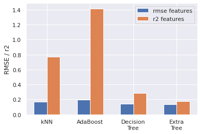

```python
rmse_woef=[model[1],rmse_ada_woef,rmse_dt_woef,rmse_exdt_woef]
r_s=[model_r2[1],r_square_ada,r_square_dt,r_square_exdt]
bar_width=0.3
x=np.arange(4)
tick_label=['kNN','AdaBoost','Decision\nTree','Extra\nTree']
plt.bar(x,rmse_woef,bar_width,label='rmse features')
plt.bar(x+bar_width,r_s,bar_width,label='r2 features')
plt.legend()
plt.xticks(x+bar_width/2,tick_label)
plt.ylabel('RMSE / r2')
plt.show()
```

## **Cluster analysis**

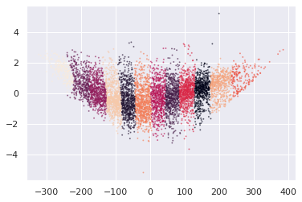

```python
from sklearn.decomposition import PCA
from sklearn.mixture import GaussianMixture
from sklearn.preprocessing import QuantileTransformer

random_state = 2
X = x_valid.values
classes = 12
n_components = 2

ts = QuantileTransformer(output_distribution='normal', random_state=random_state)
X_norm = ts.fit_transform(X)
X_pca= PCA(n_components=n_components).fit_transform(X)
X_pca[:,1] = ts.fit_transform(X_pca[:,1].reshape((-1,1))).ravel()

Y_gm = GaussianMixture(classes).fit_predict(X_pca)
plt.scatter(X_pca[:,0],X_pca[:,1],c=Y_gm,alpha=0.5,s=1)
plt.show()
```

# Multi-task Learning Model

Below we would use the Multi-task Learning concept to setup the model for training and prediction. Multi-task Learning is a subfield of machine learning in which multiple learning tasks are solved at the same time. It can accept different input data with same target or different input data and different target. Here we have 2 different input data, image data and meta data, and same training target. Since the CNN deep learning model are very good at image data training, we can setup a Multi-task Learning model combining a CNN model for image data input and a simple MLP model for meta data input.

CNN: Convolutional neural network, CNN is a class of deep neural networks, most commonly applied to analyzing visual imagery. MLP: Multilayer perceptron, MLP is a class of feedforward artificial neural network that composed of multiple layers of perceptrons (with threshold activation).

And to improve the model accuracy, we'd like to take some more ways to process the input data before feed into the model.

### Sampling would be required

We can see there is huge gap between number of the normal samples and the Melanoma samples. If we put both samples directly into model training, it may show good training accuracy but actually it may not correctly identify the Melanoma cases due to small provided samples. Therefore, we actually don't need to load all the normal samples but it would be better to make sure all the Melanoma samples are used for model training. Furthermore, it would be better to find ways to produce more Melanoma samples for training, like rotate the image for 90 degree as a new sample.

```python
print('Training dataset: Number of data with target=1: ', len(train_df[train_df['target'] == 1]))
print('Training dataset: Number of data with target=0: ', len(train_df[train_df['target'] == 0]))
```

```
Training dataset: Number of data with target=1:  584
Training dataset: Number of data with target=0:  32542
```

### Crop center of image

Checking the provided images of patient skin, we noticed that the lesion are mainly in the center of the image, the surrounding part of the lesion are mainly skin and hairs. To reduce the noice of the data, to crop the center part of the image would be a good way to improve the accuracy.

So below we define a function to crop the center part by providing the new width and height value and an example to show the difference between orignal image and cropped image.

```python
# define the function to crop the center part of the image
def crop_center(img, cropx, cropy):
    y,x = img.shape[1:3]
    startx = x//2-(cropx//2)
    starty = y//2-(cropy//2)
    return img[:,starty:starty+cropy,startx:startx+cropx:,]
```

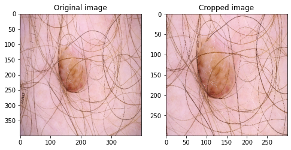

```python
image_1 = np.array([img_to_array(load_img(test_df['file_path'][0], target_size=(400,400)))])
image_1 /= 255.0
crop_image_1 = crop_center(image_1, 300, 300)

f, axarr = plt.subplots(1,2, figsize=(8,15))
axarr[0].imshow(image_1[0])
axarr[0].title.set_text("Original image")
axarr[1].imshow(crop_image_1[0])
axarr[1].title.set_text("Cropped image")
```

### Rotate 90 degree to produce new samples

As said before, it only have 584 samples of Melanoma images. But we can produce more samples by rotating the original images. Below is a sample to rotate the image for 90 degree and it will produce a new sample for the Melanoma case. And the new sample target label would be 1 and the meta data will copy the same data from the original image. Through this way, more samples can be produced to improve the model accuracy on the Melanoma case.

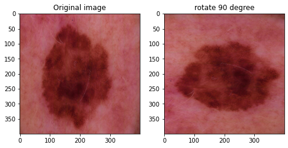

```python
train_file = train_df['file_path'][train_df['target']==1].iloc[8]
images = np.array([img_to_array(load_img(train_file, target_size=(400,400)))])
images /= 255.0
new_img = np.rot90(images[0])

f, axarr = plt.subplots(1,2, figsize=(8,15))
axarr[0].imshow(images[0])
axarr[0].title.set_text("Original image")
axarr[1].imshow(new_img)
axarr[1].title.set_text("rotate 90 degree")
```

### Split the training dataset as training data and validation data

```python
# split the dataset with 20% for validation and 80% for training
X_train, X_validate, y_train, y_validate = train_test_split(train_df, train_df['target'], test_size=0.2, random_state=9)
```

```python
X_train_cancer_len = len(X_train[X_train['target'] == 1])
X_validate_cancer_len = len(X_validate[X_validate['target'] == 1])
print("Number of Melanoma in training set:", X_train_cancer_len)
print("Number of Melanoma in validation set:", X_validate_cancer_len)
```

```
Number of Melanoma in training set: 480
Number of Melanoma in validation set: 104
```

### Customized Image Generator

There are total more than 30k images, it will cost huge memory to load all the images at once, especially with higher resolution loading parameter. At the same time, it has to keep reasonable resolution for the images to make sure the model training can locate the difference of different images. Therefore, using an image generator to provide the training and validation data would be a good solution.

Keras provided build-in ImageDataGenerator to generate the images data by defined batch size. But it also had some limitation if the provided API don't fulfill your model requirement. You can write your own image generator but it cannot support the multi-threading. Keras provided a solution that you can write your own image generator inherited from the tf.keras.utils.Sequence() class which enable multi-threading support.

Below we have written our own image generator inherited from Sequence() class providing following functions:

- Sampling a given size of normal images and all the Melanoma images for training, it will highly improve the image loading time. It also helped to balance the data volume size of normal and Melanoma images.
- Randomly select the normal image samples during the start of each epoch.
- Crop the center part of the selected images as the output for model training.
- Produce more training samples of Melanoma images by rotating the original images by 90 degrees and use the same metadata of original images.
- Output both image data and metadata for Multi-task model training

```python
class Train_Generator(Sequence):

    def __init__(self, train_df, num_samples=5000, batch_size=50, target_dim=(400, 400)):

        # separate the data in normal and cancer status
        normal_data = train_df[train_df['target'] == 0]
        cancer_data = train_df[train_df['target'] == 1]

        # shuffle the normal data and take num_samples records only to save training time
        normal_data = normal_data.sample(frac=1).reset_index(drop=True)
        normal_data = normal_data[:num_samples]

        # append the cancer data and product X and y for model training data and shuffle the sequence
        normal_data = normal_data.append(cancer_data, ignore_index=True)
        normal_data = normal_data.sample(frac=1).reset_index(drop=True)
        x_image_set = normal_data['file_path']
        y_set = normal_data['target']
        cols = [i for i in range(10)]
        cols.append('age_approx')
        x_meta_set = normal_data[cols]

        self.df = train_df
        self.x_image, self.x_meta, self.y = x_image_set, x_meta_set, y_set
        self.samples = num_samples
        self.batch_size = batch_size
        self.target_size = target_dim


    def __len__(self):
        return math.ceil(len(self.x_image) / self.batch_size)

    def __getitem__(self, idx):

        # Load the images by batch size
        batch_x = self.x_image[idx * self.batch_size:(idx + 1) * self.batch_size]
        batch_y = np.array(self.y[idx * self.batch_size:(idx + 1) * self.batch_size])
        image_x = np.array([img_to_array(load_img(img, target_size=self.target_size)) for img in batch_x])
        image_x /= 255.0

        crop_image_x = crop_center(image_x, self.target_size[0]-100, self.target_size[1]-100) # crop center of image
        meta_x = self.x_meta[idx * self.batch_size:(idx + 1) * self.batch_size] # output meta data

        # Create new data with ratating image for 90 degree for Melanoma images
        for i in range(len(batch_y)):
            if batch_y[i] == 1:
                new_img = np.rot90(crop_image_x[i])
                crop_image_x = np.concatenate((crop_image_x, [new_img]))
                batch_y = np.concatenate((batch_y, [1]))
                new_meta = meta_x.iloc[i]
                meta_x = meta_x.append(new_meta)

        return [crop_image_x, meta_x], batch_y

    def on_epoch_end(self):
        normal_data = self.df[self.df['target'] == 0]
        cancer_data = self.df[self.df['target'] == 1]

        # shuffle the normal images in each epoch ends
        normal_data = normal_data.sample(frac=1).reset_index(drop=True)
        normal_data = normal_data[:self.samples]

        normal_data = normal_data.append(cancer_data, ignore_index=True)
        normal_data = normal_data.sample(frac=1).reset_index(drop=True)
        x_image_set = normal_data['file_path']
        y_set = normal_data['target']
        cols = [i for i in range(10)]
        cols.append('age_approx')
        x_meta_set = normal_data[cols]

        self.x_image, self.x_meta, self.y = x_image_set, x_meta_set, y_set
```

### Multi-task Learning

To implement the Multi-task learning model, create 2 functions which one is for CNN and another for MLP.

For CNN model, it would go to setup 3 types of layers, the convolutional layer, pooling layer and fully connected layer.

- Convolutional layer: Apply filters to extract the images features. It consider the influence of nearby pixels
- Pooling layer：Reduce dimensionality and extract maximum of average of a region
- Fully connected layer: Aggregate information from final feature maps

For MLP model, it's more simple as a feed-forward neural network. It just have the fully connected layer which is enough for the simple data format of metadata.

```python
# create the CNN model
def create_cnn(input_dim):

    model = Sequential()

    # Convolutional layer and max pooling layer
    model.add(Conv2D(32, (3, 3), activation='relu', input_shape=input_dim))
    model.add(MaxPooling2D(pool_size=(2, 2)))

    model.add(Conv2D(64, (3, 3), activation='relu'))
    model.add(MaxPooling2D(pool_size=(2, 2)))
    #model.add(Dropout(0.25)) # we don't need dropout layer here as the optimizer would do the job

    model.add(Conv2D(128, (3, 3), activation='relu'))
    model.add(MaxPooling2D(pool_size=(2, 2)))

    model.add(Conv2D(128, (3, 3), activation='relu'))
    model.add(MaxPooling2D(pool_size=(2, 2)))
    #model.add(Dropout(0.25))

    model.add(Flatten())
    model.add(Dense(2048, activation='relu', name='deep_1'))
    model.add(Dense(1024, activation='relu', name='deep_2'))
    model.add(Dense(256, activation='relu'))
    #model.add(Dropout(0.5))

    return model
```

```python
# create the MLP model
def create_mlp(input_dim):

    model = Sequential()
    model.add(Dense(16, input_dim=input_dim, activation="relu"))
    model.add(Dense(8, activation="relu"))

    return model
```

```python
# Combine the CNN and MLP model
mlp = create_mlp(11)
cnn = create_cnn((300, 300, 3))

combinedInput = concatenate([mlp.output, cnn.output])

# Adding the classification layer
x = Dense(64, activation="relu")(combinedInput)
x = Dense(1, activation="sigmoid")(x)

model = Model(inputs=[cnn.input, mlp.input], outputs=x)

model.compile(loss='binary_crossentropy',
                  optimizer=optimizers.RMSprop(lr=1e-4),
                  metrics=['accuracy'])
model.summary()
```

```
Model: "model_1"
__________________________________________________________________________________________________
Layer (type)                    Output Shape         Param #     Connected to
==================================================================================================
conv2d_1_input (InputLayer)     (None, 300, 300, 3)  0
__________________________________________________________________________________________________
conv2d_1 (Conv2D)               (None, 298, 298, 32) 896         conv2d_1_input[0][0]
__________________________________________________________________________________________________
max_pooling2d_1 (MaxPooling2D)  (None, 149, 149, 32) 0           conv2d_1[0][0]
__________________________________________________________________________________________________
conv2d_2 (Conv2D)               (None, 147, 147, 64) 18496       max_pooling2d_1[0][0]
__________________________________________________________________________________________________
max_pooling2d_2 (MaxPooling2D)  (None, 73, 73, 64)   0           conv2d_2[0][0]
__________________________________________________________________________________________________
conv2d_3 (Conv2D)               (None, 71, 71, 128)  73856       max_pooling2d_2[0][0]
__________________________________________________________________________________________________
max_pooling2d_3 (MaxPooling2D)  (None, 35, 35, 128)  0           conv2d_3[0][0]
__________________________________________________________________________________________________
conv2d_4 (Conv2D)               (None, 33, 33, 128)  147584      max_pooling2d_3[0][0]
__________________________________________________________________________________________________
max_pooling2d_4 (MaxPooling2D)  (None, 16, 16, 128)  0           conv2d_4[0][0]
__________________________________________________________________________________________________
flatten_1 (Flatten)             (None, 32768)        0           max_pooling2d_4[0][0]
__________________________________________________________________________________________________
dense_1_input (InputLayer)      (None, 11)           0
__________________________________________________________________________________________________
deep_1 (Dense)                  (None, 2048)         67110912    flatten_1[0][0]
__________________________________________________________________________________________________
dense_1 (Dense)                 (None, 16)           192         dense_1_input[0][0]
__________________________________________________________________________________________________
deep_2 (Dense)                  (None, 1024)         2098176     deep_1[0][0]
__________________________________________________________________________________________________
dense_2 (Dense)                 (None, 8)            136         dense_1[0][0]
__________________________________________________________________________________________________
dense_3 (Dense)                 (None, 256)          262400      deep_2[0][0]
__________________________________________________________________________________________________
concatenate_1 (Concatenate)     (None, 264)          0           dense_2[0][0]
                                                                 dense_3[0][0]
__________________________________________________________________________________________________
dense_4 (Dense)                 (None, 64)           16960       concatenate_1[0][0]
__________________________________________________________________________________________________
dense_5 (Dense)                 (None, 1)            65          dense_4[0][0]
==================================================================================================
Total params: 69,729,673
Trainable params: 69,729,673
Non-trainable params: 0
__________________________________________________________________________________________________
```

```python
# define the batch size and the image loading resolution
batch_size = 50
target_dim = (400, 400)

# train the model with the customized image generator. Enable multi-thread with workers=6 and run for 8 epochs
history = model.fit_generator(
    Train_Generator(X_train, 5000, batch_size, target_dim),
    steps_per_epoch = (5000+X_train_cancer_len) // batch_size,
    validation_data = Train_Generator(X_validate, 800, batch_size, target_dim),
    validation_steps = (800+X_validate_cancer_len) // batch_size,
    epochs = 6,
    workers=6,
    use_multiprocessing=True,
    verbose = 1)
```

### Test Image Generator and Prediction

After the model is trained, a test data image generator is required to prepare the data for prediction. It's more simple compare to the training image generator. It would only require to load the test images as array format by batch size. And then output the data including metadata prepared for model prediction.

And this generator also support multi-thread so that the prediction can save processing time with worker thread as 6.

```python
# The image generator for the test dataset
class Test_Generator(Sequence):

    def __init__(self, x_image, x_meta, batch_size=50, target_dim=(200, 200)):
        self.x_files = x_image
        self.x_meta = x_meta
        self.batch_size = batch_size
        self.target_size = target_dim

    def __len__(self):
        return math.ceil(len(self.x_files) / self.batch_size)

    def __getitem__(self, idx):

        batch_x = self.x_files[idx * self.batch_size:(idx + 1) * self.batch_size]
        image_x = np.array([img_to_array(load_img(img, target_size=self.target_size)) for img in batch_x])
        image_x /= 255.0

        crop_image_x = crop_center(image_x, self.target_size[0]-100, self.target_size[1]-100)
        meta_x = self.x_meta[idx * self.batch_size:(idx + 1) * self.batch_size]

        return [crop_image_x, meta_x]
```

```python
# Use the trained model to predict the result

test_files = test_df['file_path']
cols = [i for i in range(10)]
cols.append('age_approx')
meta_data = test_df[cols]

test_predict = model.predict(Test_Generator(test_files, meta_data, batch_size, target_dim),
                                                   steps=(len(test_files) // batch_size)+1,
                                                 workers=6, use_multiprocessing=True)
```

```python
# Output the result for Kaggle submission

test_df['target'] = test_predict
test_df[['image_name', 'target']].to_csv('multitask-submission.csv', index=False)
```

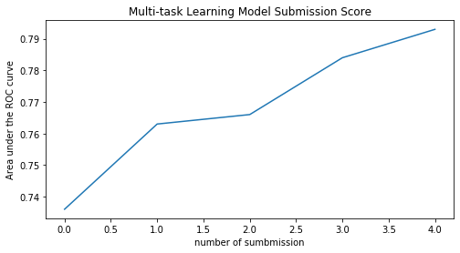

```python
plt.figure(figsize=(8,4))
AOC_score = [0.736, 0.763, 0.766, 0.784, 0.793]
plt.plot(AOC_score)
plt.xlabel('number of sumbmission')
plt.ylabel('Area under the ROC curve')
plt.title('Multi-task Learning Model Submission Score')
```

# Summary

We have used different model to train the data and come out the prediction result. Among all our models, the Mutli-task Learning model achieve the best score of 0.793. And we have some good findings to process an image dataset.

#### Long time consuming and large memory usage on image dataset

The main bottle neck are spending most of the time in loading the images into dataset. The higher resolution you set for loading the image, the longer time consuming and higher memory usage is required. Therefore, we take different ways to solve the problem. Using image generator to load them by batch, enable multi-thread to reduce loading time, directly calculate RGB data and store average() etc to reduce memory usage.

#### Identify image pattern is important

To solve an image classification problem, identify the image pattern(features) is important. We mainly took 2 ways. One is to extract the RGB information of the image and perform some of the image processing technique to come out the key image pattern. Another one is to use CNN model and make use of convolutional layer/pooling layer to extract image features.

#### sampling is required to balance samples in different target

There is huge gap between the normal samples and the Melanoma samples. It need to find ways to balance a bit the training samples of the 2 different targets. Otherwise the model may have very good training accuracy but actually it cannot identify the Melanoma cases. We have tried some ways to solve this problem through sampling method and producing more new samples.

#### Further improvement

We thought the model we have built can be used to detect the Melanoma cases. When the patient upload a picture of the skin image, the model can come out a probability value to indicate how close it's Melanoma. But still, there are lots of improvement areas to be investigate to improve the model accuracy. For example, we haven't finished the modeling for the case that one patient have several images, considering this situation to improve accuracy.